# Intro to data analytics with Tidyverse

GDG Lisbon 2017-11-11

This is an introduction to data analytics with the *tidyverse* tools. We will look over several functions and packages included in *tidyverse* and the reason why we use these tools. As organiser of an R-Ladies community, I heard more than once that doing analytics and data science with **R** is not an easy thing because of the language, I always answer the same thing: first learn *tidyverse*, get used to the language, and then you’ll find a bunch of new possibilities!

This notebook goes with the presentation which contains the main points of the code below.

### The tidyverse

*Tidyverse* is a collection of R packages to cover the Data Science path. What do I mean? With this collection we can *import*, *tidy*, *wrangle*, *visualise*, and *model* data, which is basically the path of data.

The list below has all packages in the collection: The bold lines are the core of tidyverse which are loaded with `library(tidyverse)`.

Import

- **[readr](http://readr.tidyverse.org/)**: fast and friendly way to read rectangular data.
- [readxl](http://readxl.tidyverse.org/): get data out of Excel and into R.
- [haven](http://haven.tidyverse.org/): read and write various data formats used by other statistical packages.
- [dbplyr](http://dbplyr.tidyverse.org/): database backend for dplyr.

Wrangle

- **[tidyr](http://tidyr.tidyverse.org/)**: create tidy data.
- **[dplyr](http://dplyr.tidyverse.org/)**: data manipulation.
- **[ggplot2](http://ggplot2.tidyverse.org/)**: declaratively creating graphic.
- **[tibble](http://tibble.tidyverse.org/)**: modern reimagining of the data.frame.
- **[stringr](http://stringr.tidyverse.org/)**: work with strings as easy as posssible.
- [lubridate](http://lubridate.tidyverse.org/): work with date-times.
- [forcats](http://forcats.tidyverse.org/): tools that solve common problems with factors.
- hms: storing durations or time-of-day values.
- blob: represent a vector of binary objects.

Program

- **[purrr](http://purrr.tidyverse.org/)**: functional programming (FP) toolkit.
- [rlang](http://rlang.tidyverse.org/): tools to work with core language features.
- [magrittr](http://magrittr.tidyverse.org/): make your code more readable.
- glue: Glue strings to data.

Model

- modelr: help you create elegant pipelines when modelling.
- broom: messy output of built-in functions and turns them into tidy data frames.

Share - [reprexr](http://reprex.tidyverse.org/): Prepare reprexes (reproducible examples).

### base:: vs tidyverse::

I won’t go into why you could find R difficult, there’s multiple reasons why you shouldn’t find it intuitive or unhelpful. What I’m going to do is to name advantages of the *tidyverse* over *base* that if you keep coding with R you would find on your own:

- Easy grammar.
- Human readable.
- Consistent syntax.
- Coverage workflow.

### Let’s get the party started

#### Load dependencies

```r
knitr::opts_chunk$set(message=FALSE, warning = FALSE)
require(tidyverse)
```

Loading tidyverse will only give us the core of the collection (*tidyr*, *stringr*, *dplyr*, *ggplot2*, *tibble*, *purrr*), so if we need any other package along the example we will load it or call a standalone function when we need it.

We use require in case we don’t have the library downloaded it will do that, and for the data package it is not needed because it comes with the RStudio packages.

#### Import & tidy data

To get to the good stuff sooner, let’s import a clean dataset and see if there’s something we would like to tidy or add. We are going to load *repurrrsive* which contains *sw_people*, *sw_films*, *sw_species*, *sw_planets*, *sw_starships* and *sw_vehicles* lists interrelated. This is similar to the data you’ll find if you import a JSON.

Let’s inspect a bit of the data and put it in an rectangular form.

```r
library(repurrrsive)
str(sw_people[1])
```

```
List of 1
 $ :List of 16
  ..$ name      : chr "Luke Skywalker"
  ..$ height    : chr "172"
  ..$ mass      : chr "77"
  ..$ hair_color: chr "blond"
  ..$ skin_color: chr "fair"
  ..$ eye_color : chr "blue"
  ..$ birth_year: chr "19BBY"
  ..$ gender    : chr "male"
  ..$ homeworld : chr "http://swapi.co/api/planets/1/"
  ..$ films     : chr [1:5] "http://swapi.co/api/films/6/" "http://swapi.co/api/films/3/" "http://swapi.co/api/films/2/" "http://swapi.co/api/films/1/" ...
  ..$ species   : chr "http://swapi.co/api/species/1/"
  ..$ vehicles  : chr [1:2] "http://swapi.co/api/vehicles/14/" "http://swapi.co/api/vehicles/30/"
  ..$ starships : chr [1:2] "http://swapi.co/api/starships/12/" "http://swapi.co/api/starships/22/"
  ..$ created   : chr "2014-12-09T13:50:51.644000Z"
  ..$ edited    : chr "2014-12-20T21:17:56.891000Z"
  ..$ url       : chr "http://swapi.co/api/people/1/"
```

```r
## With tidyverse
people_tbl <- tibble(
  name    = sw_people %>% map_chr("name"),
  films   = sw_people %>% map("films"),
  height  = sw_people %>% map_chr("height") %>%
    readr::parse_number(na = "unknown"),
  eye_color = sw_people %>% map_chr("eye_color"),
  species = sw_people %>% map_chr("species", .null = NA_character_)
)
people_tbl %>% head()
```

| name | films | height | eye_color | species |
| --- | --- | --- | --- | --- |
| Luke Skywalker |  | 172 | blue | http://swapi.co/api/species/1/ |
| C-3PO |  | 167 | yellow | http://swapi.co/api/species/2/ |
| R2-D2 |  | 96 | red | http://swapi.co/api/species/2/ |
| Darth Vader |  | 202 | yellow | http://swapi.co/api/species/1/ |
| Leia Organa |  | 150 | brown | http://swapi.co/api/species/1/ |
| Owen Lars |  | 178 | blue | http://swapi.co/api/species/1/ |

```r
people_tbl %>% nrow()
```

```
[1] 87
```

See what I used there? I used the **infix operator %>%** which is defined by the package *magrittr* and heavily used in *dplyr*. We imported it before, when we called the library *tidyverse*. It works like a pipe, it passes the left side of the pipe to the first argument of the right side. And if you are assigning that, the last handling is what the variable gets.

So, instead of calling `head(people_tbl)`, I called `people_tbl %>% head()`. Here it doesn’t make any difference but our workflow will improve thanks to the pipe.

```r
## Without tidyverse
people_names <- sapply(sw_people, '[[', 'name')
people_films <- sapply(sw_people, function(x) x[['films']])
people_height <- sapply(sw_people, function(x) x[['height']])
people_height[people_height == 'unknown'] <- NA
people_eye_color <- sapply(sw_people, '[[', 'eye_color')
people_species <- unlist(sapply(sw_people, '[[', 'species'))
people_species[people_species == NULL] <- NA
people_no <- do.call(rbind.data.frame, Map(cbind, people_names, people_films,
                                           people_height, people_eye_color,
                                           people_species))
colnames(people_no) <- c('name', 'films', 'height', 'eye_color', 'species')
rownames(people_no) <- c()
```

Let’s count the number of films in which every character has participated and discard the *films* column.

```r
people_tbl <- people_tbl %>%
  mutate(
    n_films = map_int(films, length)
  ) %>%
  select(-films)
people_tbl
```

| name | height | eye_color | species | n_films |
| --- | --- | --- | --- | --- |
| Luke Skywalker | 172 | blue | http://swapi.co/api/species/1/ | 5 |
| C-3PO | 167 | yellow | http://swapi.co/api/species/2/ | 6 |
| R2-D2 | 96 | red | http://swapi.co/api/species/2/ | 7 |
| Darth Vader | 202 | yellow | http://swapi.co/api/species/1/ | 4 |
| Leia Organa | 150 | brown | http://swapi.co/api/species/1/ | 5 |
| Owen Lars | 178 | blue | http://swapi.co/api/species/1/ | 3 |
| Beru Whitesun lars | 165 | blue | http://swapi.co/api/species/1/ | 3 |
| R5-D4 | 97 | red | http://swapi.co/api/species/2/ | 1 |
| Biggs Darklighter | 183 | brown | http://swapi.co/api/species/1/ | 1 |
| Obi-Wan Kenobi | 182 | blue-gray | http://swapi.co/api/species/1/ | 6 |

[output cut: 77 more lines]

This looks almost tidy.

What are those species? Let’s look them in the *sw_species* list.

```r
species_tbl <- tibble(
  specie      = sw_species %>% map_chr("name"),
  language  = sw_species %>% map_chr("language"),
  url       = sw_species %>% map_chr("url")
)
species_tbl
```

| specie | language | url |
| --- | --- | --- |
| Hutt | Huttese | http://swapi.co/api/species/5/ |
| Yoda's species | Galactic basic | http://swapi.co/api/species/6/ |
| Trandoshan | Dosh | http://swapi.co/api/species/7/ |
| Mon Calamari | Mon Calamarian | http://swapi.co/api/species/8/ |
| Ewok | Ewokese | http://swapi.co/api/species/9/ |
| Sullustan | Sullutese | http://swapi.co/api/species/10/ |
| Neimodian | Neimoidia | http://swapi.co/api/species/11/ |
| Gungan | Gungan basic | http://swapi.co/api/species/12/ |
| Toydarian | Toydarian | http://swapi.co/api/species/13/ |
| Dug | Dugese | http://swapi.co/api/species/14/ |

[output cut: 27 more lines]

```r
people_tbl <- left_join(people_tbl, species_tbl, by = c("species" = "url")) %>%
  select(-species)
```

#### Wragling data

Let’s explore our data! 💃

Out of curiosity, let’s see which specie has more blue-eyed people.

```r
blue_eyed <- people_tbl %>%
  filter(eye_color == 'blue')
blue_eyed
```

| name | height | eye_color | n_films | specie | language |
| --- | --- | --- | --- | --- | --- |
| Luke Skywalker | 172 | blue | 5 | Human | Galactic Basic |
| Owen Lars | 178 | blue | 3 | Human | Galactic Basic |
| Beru Whitesun lars | 165 | blue | 3 | Human | Galactic Basic |
| Anakin Skywalker | 188 | blue | 3 | Human | Galactic Basic |
| Wilhuff Tarkin | 180 | blue | 2 | Human | Galactic Basic |
| Chewbacca | 228 | blue | 5 | Wookiee | Shyriiwook |
| Jek Tono Porkins | 180 | blue | 1 | Human | Galactic Basic |
| Lobot | 175 | blue | 1 | Human | Galactic Basic |
| Mon Mothma | 150 | blue | 1 | Human | Galactic Basic |
| Qui-Gon Jinn | 193 | blue | 1 | Human | Galactic Basic |

[output cut: 9 more lines]

```r
blue_eyed <- blue_eyed %>%
  group_by(specie) %>%
  summarise(count = n())
blue_eyed
```

| specie | count |
| --- | --- |
| Chagrian | 1 |
| Human | 12 |
| Mirialan | 2 |
| Tholothian | 1 |
| Wookiee | 2 |
| NA | 1 |

```r
blue_eyed <- blue_eyed%>%
  arrange(desc(count)) %>%
  head(1)
blue_eyed
```

| specie | count |
| --- | --- |
| Human | 12 |

Now, let’s use a bit of visualization to explore the data visually to use the knowledge in our model.

```r
summary(people_tbl)
```

```
     name               height       eye_color            n_films         specie
 Length:87          Min.   : 66.0   Length:87          Min.   :1.000   Length:87
 Class :character   1st Qu.:167.0   Class :character   1st Qu.:1.000   Class :character
 Mode  :character   Median :180.0   Mode  :character   Median :1.000   Mode  :character
                    Mean   :174.4                      Mean   :1.989
                    3rd Qu.:191.0                      3rd Qu.:3.000
                    Max.   :264.0                      Max.   :7.000
                    NA's   :6
   language
 Length:87
 Class :character
 Mode  :character
```

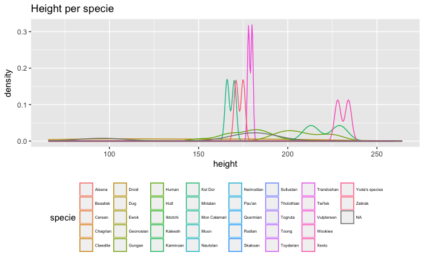

```r
ggplot(people_tbl, aes(height, color = specie)) +
  geom_density(alpha = 0.5) +
  theme(legend.position="bottom") +
  labs(title="Height per specie") +
  theme(legend.text=element_text(size=5)) +
  guides(color=guide_legend(ncol=9))
```

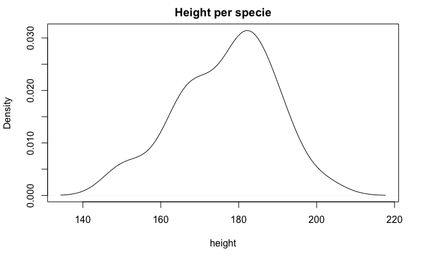

```r
## Without tidyverse
height_vul <- people_tbl$height[people_tbl$specie == 'Human']
height_vul <- height_vul[!(is.na(height_vul))]
plot(density(height_vul), main="Height per specie", xlab="height")
```

#### Model

To model the data let’s put all we learnt in practice with another - bigger - dataset and predict.

```r
library(readr)
library(modelr)
library(broom)
library(randomForest)
wine_quality <- read_csv2('https://raw.githubusercontent.com/chucheria/2017_GDGLisbon/master/winequality-white.csv')
wine_quality <- wine_quality %>%
  mutate_if(is.character, as.double)
summary(wine_quality)
```

```
 fixed acidity    volatile acidity  citric acid     residual sugar     chlorides       free sulfur dioxide
 Min.   :  5.00   Min.   :0.0800   Min.   :0.0000   Min.   : 0.600   Min.   :0.00900   Min.   :   2.00
 1st Qu.: 61.00   1st Qu.:0.2100   1st Qu.:0.2700   1st Qu.: 1.700   1st Qu.:0.03600   1st Qu.:  23.00
 Median : 67.00   Median :0.2600   Median :0.3200   Median : 5.200   Median :0.04300   Median :  34.00
 Mean   : 62.41   Mean   :0.2782   Mean   :0.3342   Mean   : 6.391   Mean   :0.04577   Mean   :  41.01
 3rd Qu.: 73.00   3rd Qu.:0.3200   3rd Qu.:0.3900   3rd Qu.: 9.900   3rd Qu.:0.05000   3rd Qu.:  46.00
 Max.   :715.00   Max.   :1.1000   Max.   :1.6600   Max.   :65.800   Max.   :0.34600   Max.   :1465.00
 total sulfur dioxide    density             pH          sulphates         alcohol             quality
 Min.   :   9.0       Min.   :0.9871   Min.   :  3.0   Min.   :0.2200   Min.   :8.000e+00   Min.   :3.000
 1st Qu.: 108.0       1st Qu.:0.9917   1st Qu.:304.0   1st Qu.:0.4100   1st Qu.:9.200e+01   1st Qu.:5.000
 Median : 134.0       Median :0.9937   Median :316.0   Median :0.4700   Median :1.010e+02   Median :6.000
 Mean   : 148.6       Mean   :0.9940   Mean   :287.1   Mean   :0.4898   Mean   :1.823e+12   Mean   :5.878
 3rd Qu.: 167.8       3rd Qu.:0.9961   3rd Qu.:326.0   3rd Qu.:0.5500   3rd Qu.:1.130e+02   3rd Qu.:6.000
 Max.   :3665.0       Max.   :1.0390   Max.   :382.0   Max.   :1.0800   Max.   :9.733e+14   Max.   :9.000
```

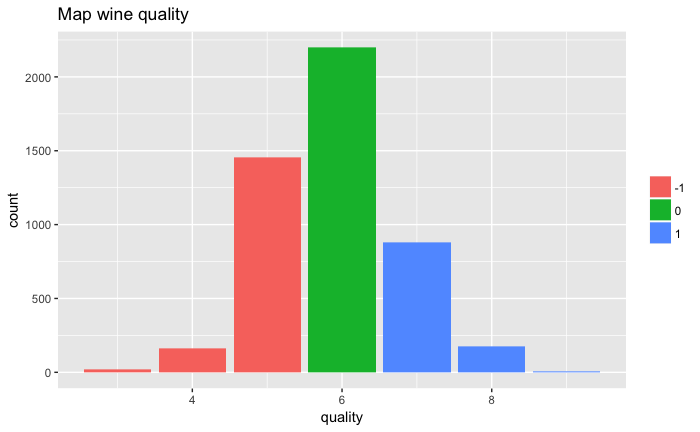

```r
wine_quality <- wine_quality %>%
  mutate(taste = ifelse(quality > 6, 1,
                        ifelse(quality == 6, 0, -1)))
ggplot(wine_quality, aes(quality, fill = factor(taste))) +
  geom_bar() +
  labs(title='Map wine quality') +
  guides(fill=guide_legend(title=NULL))
```

```r
model_lm <- lm(formula = taste ~ quality, data = wine_quality)
model_rf <- randomForest(formula = taste ~ quality, data = wine_quality)
model_lm %>% tidy()
```

| term | estimate | std.error | statistic | p.value |
| --- | --- | --- | --- | --- |
| (Intercept) | -4.7356511 | 0.02215544 | -213.7467 | 0 |
| quality | 0.7855234 | 0.00372721 | 210.7538 | 0 |

```r
model_lm %>%
    augment() %>%
    head()
```

|  | taste | quality | .fitted | .se.fit | .resid | .hat | .sigma | .cooksd | .std.resid |
| --- | --- | --- | --- | --- | --- | --- | --- | --- | --- |
| 1 | 0 | 6 | -0.02251062 | 0.003331845 | 0.02251062 | 0.0002080458 | 0.2310199 | 9.882654e-07 | 0.09746017 |
| 2 | 0 | 6 | -0.02251062 | 0.003331845 | 0.02251062 | 0.0002080458 | 0.2310199 | 9.882654e-07 | 0.09746017 |
| 3 | 0 | 6 | -0.02251062 | 0.003331845 | 0.02251062 | 0.0002080458 | 0.2310199 | 9.882654e-07 | 0.09746017 |
| 4 | 0 | 6 | -0.02251062 | 0.003331845 | 0.02251062 | 0.0002080458 | 0.2310199 | 9.882654e-07 | 0.09746017 |
| 5 | 0 | 6 | -0.02251062 | 0.003331845 | 0.02251062 | 0.0002080458 | 0.2310199 | 9.882654e-07 | 0.09746017 |
| 6 | 0 | 6 | -0.02251062 | 0.003331845 | 0.02251062 | 0.0002080458 | 0.2310199 | 9.882654e-07 | 0.09746017 |

```r
grid_gather <- data_grid(wine_quality, quality, .model = model_lm) %>%
    gather_predictions(model_lm, model_rf)
grid_gather %>% head()
```

| model | quality | pred |
| --- | --- | --- |
| model_lm | 3 | -2.37908087 |
| model_lm | 4 | -1.59355745 |
| model_lm | 5 | -0.80803403 |
| model_lm | 6 | -0.02251062 |
| model_lm | 7 | 0.76301280 |
| model_lm | 8 | 1.54853622 |

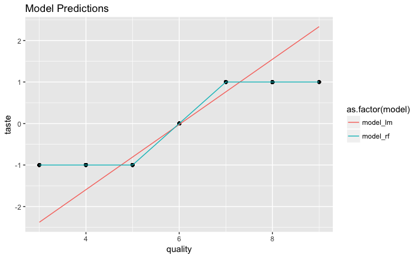

```r
ggplot(data = wine_quality, aes(x = quality, y = taste)) +
  geom_point() +
  geom_line(data = grid_gather, aes(x = quality, y = pred, color = as.factor(model))) +
  ggtitle("Model Predictions")
```

Obviously, linear models are no good in this case for classification but the example fits to see all the advantages modelr and broom gives you in your model workflow.

### Conclusion

Tidyverse will give you a flexibility you only can dream with R. Of course it is very specific to data analytics and to play with data but it will introduce you to R nicely which at the end gives you a lot of possibilities. From analytics to creating your own website with R.

### Resources

- [R for Data Science - Garrett Grolemund & Hadley Wickham](http://r4ds.had.co.nz/)
- [Tidyverse](https://www.tidyverse.org/)
- [Hadley Wickham](http://hadley.nz/)
- [Teaching data science to new useRs - Mine Cetinkaya-Rundel](https://channel9.msdn.com/Events/useR-international-R-User-conferences/useR-International-R-User-2017-Conference/KEYNOTE-Teaching-data-science-to-new-useRs)
- [Tidy Data](https://cran.r-project.org/web/packages/tidyr/vignettes/tidy-data.html)